# Práctica 2.2: Explotación Paralelismo de Hilos

- Objetivos
  - Ejercicio 1: Hello World
  - Ejercicio 2: Directivas de trabajo compartido
    - Expresión de paralelismo
    - ToDo
  - Ejercicio 3: Condiciones de Carrera
  - Ejercicio 4: Tareas OMP
    - A tener en cuenta
- Tareas a realizar por el alumno
  - Tareas a considerar
  - Ejercicio 5: Quick-sort
  - Ejercicio 6: K-means
    - ¿Como funciona el algoritmo?
    - ToDo
- Herramienta de perfilado VTune
  - Intel VTune
    - 0.0.1 Comienzo Herramienta
  - Opciones de análisis
    - Intel VTune: Análisis Hotspots
    - Intel VTune: Parallelism Analysis
    - Intel VTune: Threading Efficiency
  - Intel VTune: Threading Efficiency
    - Intel VTune: Microachitecture

# Objetivos

Esta práctica persigue que los estudiantes se familiaricen con la mejora de rendimiento por la explotación de paralelismo TLP mediante el uso de OpenMP. Este esquema de paralelismo es compatible con los estudiados hasta el momento en la asignatura.

## Ejercicio 1: Hello World

El código “hello.c” versará sobre la compilación y control de hilos de ejecución

```c
#include <stdio.h>
#include <omp.h>

int main(){

    // This code is executed by 1 thread
    printf("OpenMP with %d max threads\n", omp_get_max_threads () );
    printf("OpenMP with %d procs available\n", omp_get_num_procs () );

    #pragma omp parallel
    {
    // This code is executed in parallel
    // by multiple threads
    printf("Hello World from thread %d of %d threads\n",
        omp_get_thread_num(), omp_get_num_threads() );
    }
}
```

- Pudiendo compilar con ambos compiladores y generando el fichero de reportes

```bash
user@lab:~ $ icx -o hello.icx hello.c -qopenmp -qopt-report=1
user@lab:~ $ more hello.optrpt

...
COMPILE FUNC: main
   -> BROKER: __kmpc_fork_call hello.c(14,2)(main.extracted)
```

- Para controlar el número de hilos de ejecución se puede hacer de varias formas:
  - Con la variable de entorno *OMP_NUM_THREADS*
  - En la pragma `#pragma omp parallel num_threads(3)`

```bash
user@lab:~ $ export OMP_NUM_THREADS=3
user@lab:~ $ ./hello.icx
OpenMP with 3 max threads
OpenMP with 4 procs available
Hello World from thread 0 of 3 threads
Hello World from thread 1 of 3 threads
Hello World from thread 2 of 3 threads
```

- Para controlar el tipo de cores (P-cores o E-cores) donde ejecutar el código se recomiendo emplear el comando `taskset`

```bash
user@lab:~ $ OMP_NUM_THREADS=2 taskset --cpu-list 0,1 ./hello.icx
OpenMP with 2 max threads
OpenMP with 2 procs available
Hello World from thread 0 of 2 threads
Hello World from thread 1 of 2 threads
```

## Ejercicio 2: Directivas de trabajo compartido

- En OpenMP existen varias formas de explicitar la distribución del trabajo entre los hilos
  - `#pragma omp for/#pragma omp parallel for` para distribuir las iteraciones de los bucles entre los hilos disponibles
  - `#pragma omp sections` para crear secciones de código concurrente entre hilos
  - `#pragma omp single` para expresar una región secuencial dentro de una región paralela
- En este ejemplo, el código **prime.c** trabaja dos aspectos:
  - Distribución de trabajo entre hilos
  - Gestión de variables (privadas, compartidas…)
- El ejemplo “prime.c” calcula los números primos menores a un determinado **n** (parámetro de entrada)
  - **i** es primo si no tiene divisores (2, *i*/2)
  - `#define DEBUG` visualiza la lista de primos

```c
    //#pragma omp parallel...
    for (i=2; i<n; i++)
    {
        not_flag = 0;
        j=2;
        while(j<=i/2 && !not_flag)
        {
            if(i%j==0) // not prime
                not_flag=1;
            j++;
        }
        if (j>=i/2 && !not_flag)
            primes[++k] = i;
    }
```

### Expresión de paralelismo

- Iteraciones del bucle **i** potencialmente paralelas
  - Iteraciones independientes
- A tener en cuenta
  - Uso de variables: privadas, compartidas…. ect
  - Variable `++k` es el índice de la lista de números primos
    - Posible carrera: problema **read&update&write**
    - Solución: `#omp critical`
    - Lista desordenada: implementar un *sort(primes)*

### ToDo

- **A Evaluar** Se recomienda estudiar el impacto de las diferentes políticas de distribución de carga
  - *STATIC*
  - *STATIC, chunk*
  - *DYNAMIC[, chunk]*
  - *GUIDED[, chunk]*
  - *AUTO*

## Ejercicio 3: Condiciones de Carrera

- El tercer ejercicio se basa en el código “trapezoidal.c” que calcula la integral mediante el método del trapecio de acuerdo a la siguiente ecuación
  - Area del trapecio $S=\frac{1}{2}(f(a')+f(b'))*h$
  - Integral como suma de trapecios: $\int_{a}^{b} f(x) \partial x = \sum \frac{f(a')+f(b')}{2}h$

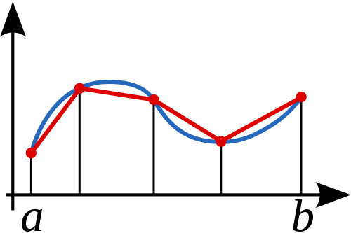

Aproximación de integral a trapezoide

- Podemos destacar **dos tipos tareas**:
  - Cálculo de areas de cada trapecio individual
  - Acumulación de trapecios (*integral*) donde potencialmente pueden aparecer condiciones de carrera

```c
double Trap(double a, double b, int n, double h) {
    double integral, area;
    int k;

    integral = 0.0;
    for (k = 1; k <= n; k++) {
        area = h*(f(a+k*h)+f(a+(k-1)*h))/2.0;
        integral+=area;
    }

    return integral;
}  /* Trap */
```